```
============================================
; Title:       Logistic Regression — Amazon Alexa Reviews
;              Sentiment Classification
; Author:      Hali Sarah Parsons
; Date:        14 April 2026
; Modified By: N/A
; Description: Builds a logistic regression model to classify Amazon
;              Alexa reviews as positive (1) or negative (0) feedback.
;              Includes TF-IDF vectorization, train/test split,
;              a custom ModelPerformanceEvaluator class mirroring
;              Sarkar (2019) page 335, confusion matrix, and
;              out-of-sample prediction on custom review text.
============================================
```

# Logistic Regression — Amazon Alexa Reviews Sentiment Classification

**Hali Sarah Parsons | BU 360 | 14 April 2026**

## Overview

This notebook builds a logistic regression model to classify Amazon Alexa product reviews as positive (feedback = 1) or negative (feedback = 0). The dataset contains 3,150 verified reviews from Amazon customers about Alexa Echo, Echo Dot, and Firestick products.

The pipeline follows the pattern from Chapter 5 of Sarkar (2019): clean the text, vectorize with TF-IDF, train the classifier, evaluate performance, and test on out-of-sample input. The assignment also asks for a custom model performance class that mirrors the output structure described on pages 335–337 of the textbook — that class is built here from scratch and applied to the logistic regression results.

**Data diary question:** Can the language in a short Amazon review reliably predict whether a customer left positive or negative feedback — and what does the model struggle with?

## Imports

```python
# ============================================
# IMPORTS
#
# pandas / numpy — data loading, manipulation, and array operations.
# re — regex for text cleaning (removing punctuation, URLs).
# nltk stopwords — English function words to remove before vectorizing.
# train_test_split — splits data into training and test sets.
# TfidfVectorizer — converts cleaned text into TF-IDF feature vectors.
# LogisticRegression — the classifier we're building and evaluating.
# metrics — accuracy, precision, recall, F1, classification report,
#           and confusion matrix for model evaluation.
# matplotlib — renders the confusion matrix heatmap.
# ============================================
import pandas as pd
import numpy as np
import re
import matplotlib.pyplot as plt
import matplotlib.ticker as ticker
import nltk
nltk.download('stopwords', quiet=True)
from nltk.corpus import stopwords
from sklearn.model_selection import train_test_split
from sklearn.feature_extraction.text import TfidfVectorizer
from sklearn.linear_model import LogisticRegression
from sklearn.metrics import (accuracy_score, precision_score, recall_score,
                              f1_score, classification_report, confusion_matrix)

%matplotlib inline
print("All libraries imported successfully.")
```

```
All libraries imported successfully.
```

## Step 1: Load and Explore the Data

Before writing any model code, I want to understand what the data actually looks like — column names, class distribution, and whether there are any missing values that need handling. The most important thing to check is class balance: if 95% of reviews are positive, a model that always predicts positive will score 95% accuracy while doing nothing useful.

```python
# ============================================
# LOAD DATA
#
# The file is TSV (tab-separated) not CSV — sep='\t' is required.
# encoding='utf-8-sig' handles the BOM character at the start of
# the file that would otherwise corrupt the first column name.
# ============================================
df = pd.read_csv('amazon_alexa.tsv', sep='\t', encoding='utf-8-sig')

print(f"Dataset shape: {df.shape}")
print(f"\nColumns: {list(df.columns)}")
print(f"\nFeedback distribution:")
print(df['feedback'].value_counts())
print(f"\nClass balance: {df['feedback'].mean()*100:.1f}% positive")
print(f"\nMissing values:")
print(df.isnull().sum())
print(f"\nSample reviews:")
for _, row in df.sample(5, random_state=42).iterrows():
    label = 'POSITIVE' if row['feedback'] == 1 else 'NEGATIVE'
    print(f"  [{label}] {str(row['verified_reviews'])[:90]}")
```

```
Dataset shape: (3150, 5)

Columns: ['rating', 'date', 'variation', 'verified_reviews', 'feedback']

Feedback distribution:
feedback
1    2893
0     257
Name: count, dtype: int64

Class balance: 91.8% positive

Missing values:
rating              0
date                0
variation           0
verified_reviews    1
feedback            0
dtype: int64

Sample reviews:
  [POSITIVE] Love it, we are still learning the capabilities, having a lot of fun.
  [POSITIVE] Very easy setup.
  [POSITIVE]
  [POSITIVE] I purchased this on prime day mostly as a present for myself because I found having the ec
  [POSITIVE] Fun and  information.  No dislikes  so far !! Like the convenience!!
```

### Observation — Data Exploration

The class imbalance here is significant — 91.8% of reviews are positive (feedback = 1) and only 8.2% are negative. A model that predicted positive for every review would achieve 91.8% accuracy without learning anything about language. This is why accuracy alone is a misleading metric for this dataset and why precision, recall, and F1 for the minority class (negative) matter more than the headline accuracy number.

There is one missing value in `verified_reviews` — a single row with no review text. That row gets dropped before training since there is nothing to vectorize.

## Step 2: Text Cleaning

TF-IDF doesn't need the kind of deep normalization pipeline we built for BU 360's earlier assignments. For classification, the key steps are lowercasing, removing noise (punctuation, URLs, numbers), and stripping stop words. Lemmatization would help but adds runtime — for this dataset size the simpler pipeline performs well enough to demonstrate the model clearly.

```python
# ============================================
# TEXT CLEANING FUNCTION
#
# Each step removes a specific type of noise:
#   lowercase   — standardizes capitalization so 'Love' and 'love'
#                 are treated as the same token
#   URL removal — URLs create unique tokens that don't generalize
#   non-alpha   — punctuation and numbers stripped; we want content words
#   stop words  — function words (the, and, is) add noise without signal
#   length > 1  — single characters left after stripping are meaningless
#
# The function returns a single cleaned string per review,
# ready to pass to TfidfVectorizer.
# ============================================
stop_words = set(stopwords.words('english'))

def clean_text(text):
    """Clean a single review string for TF-IDF vectorization."""
    text = str(text).lower()
    text = re.sub(r'http\S+|www\S+', '', text)   # remove URLs
    text = re.sub(r'[^a-z\s]', '', text)          # keep only letters and spaces
    tokens = text.split()
    # Remove stop words and single-character tokens
    tokens = [t for t in tokens if t not in stop_words and len(t) > 1]
    return ' '.join(tokens)

# Drop the one row with missing review text before cleaning
df = df.dropna(subset=['verified_reviews']).copy()

# Apply cleaning to every review
df['cleaned'] = df['verified_reviews'].apply(clean_text)

print("Text cleaning complete.")
print(f"\nBefore cleaning: {df['verified_reviews'].iloc[3]}")
print(f"\nAfter cleaning:  {df['cleaned'].iloc[3]}")
print(f"\nAverage cleaned review length: {df['cleaned'].str.split().str.len().mean():.1f} tokens")
```

```
Text cleaning complete.

Before cleaning: I have had a lot of fun with this thing. My 4 yr old learns about dinosaurs, i control the lights and play games like categories. Has nice sound when playing music as well.

After cleaning:  lot fun thing yr old learns dinosaurs control lights play games like categories nice sound playing music well

Average cleaned review length: 12.7 tokens
```

## Step 3: Train/Test Split and TF-IDF Vectorization

The `stratify=y` parameter in `train_test_split` ensures the 91.8%/8.2% positive/negative ratio is preserved in both the training and test sets. Without stratification, random chance could put most of the rare negative reviews in one set, making either training or evaluation unreliable.

The TF-IDF vectorizer uses bigrams (`ngram_range=(1,2)`) in addition to unigrams. This captures two-word phrases like "love alexa" or "not working" that carry more signal than either word alone — exactly the kind of context that pure Bag of Words loses.

```python
# ============================================
# TRAIN/TEST SPLIT AND TF-IDF VECTORIZATION
#
# test_size=0.2 reserves 20% of the data for evaluation.
# stratify=y preserves the class ratio in both splits — critical
# for imbalanced datasets so the model sees both classes during
# training and evaluation reflects real-world class distribution.
#
# TfidfVectorizer settings:
#   min_df=2      — ignore tokens appearing in fewer than 2 documents
#                   (one-off typos and proper nouns that don't generalize)
#   max_df=0.95   — ignore tokens appearing in >95% of documents
#                   (near-universal words that stop words missed)
#   ngram_range=(1,2) — include unigrams and bigrams for phrase context
#
# fit_transform on training data, transform-only on test data —
# the vocabulary is learned from training and applied to test,
# never the other way around (that would be data leakage).
# ============================================
X = df['cleaned']
y = df['feedback']

X_train, X_test, y_train, y_test = train_test_split(
    X, y, test_size=0.2, random_state=42, stratify=y
)

print(f"Training set: {len(X_train)} reviews")
print(f"  Positive: {y_train.sum()} | Negative: {(y_train==0).sum()}")
print(f"\nTest set: {len(X_test)} reviews")
print(f"  Positive: {y_test.sum()} | Negative: {(y_test==0).sum()}")

# Build TF-IDF features
tv = TfidfVectorizer(min_df=2, max_df=0.95, ngram_range=(1, 2))
X_train_tfidf = tv.fit_transform(X_train)
X_test_tfidf  = tv.transform(X_test)

print(f"\nTF-IDF vocabulary size: {len(tv.vocabulary_):,} features")
print(f"Training matrix shape:  {X_train_tfidf.shape}")
print(f"Test matrix shape:      {X_test_tfidf.shape}")
```

```
Training set: 2519 reviews
  Positive: 2314 | Negative: 205

Test set: 630 reviews
  Positive: 579 | Negative: 51
```

```
TF-IDF vocabulary size: 7,320 features
Training matrix shape:  (2519, 7320)
Test matrix shape:      (630, 7320)
```

## Step 4: Train the Logistic Regression Model

Logistic regression is a natural fit for binary classification problems like this one. Unlike Naïve Bayes which assumes word independence, logistic regression learns a weight for each feature (TF-IDF token) that pushes the predicted probability toward positive or negative. The `class_weight='balanced'` parameter compensates for the imbalanced dataset by giving negative reviews more influence during training — without it, the model would learn to mostly predict positive and achieve high accuracy while ignoring the minority class.

```python
# ============================================
# TRAIN LOGISTIC REGRESSION
#
# class_weight='balanced' — automatically adjusts weights inversely
#   proportional to class frequency. With 91.8% positive reviews,
#   negative reviews are weighted ~11x higher during training.
#   This prevents the model from learning to always predict positive.
#
# max_iter=1000 — logistic regression uses an iterative solver.
#   The default 100 iterations sometimes doesn't converge on
#   high-dimensional TF-IDF data. 1000 ensures convergence.
#
# random_state=42 — makes results reproducible.
# ============================================
lr_model = LogisticRegression(
    max_iter=1000,
    random_state=42,
    class_weight='balanced'
)

lr_model.fit(X_train_tfidf, y_train)

# Generate predictions on the test set
lr_predictions = lr_model.predict(X_test_tfidf)

print("Logistic Regression model trained successfully.")
print(f"\nPrediction breakdown on test set:")
pred_counts = pd.Series(lr_predictions).value_counts()
print(f"  Predicted Positive (1): {pred_counts.get(1, 0)}")
print(f"  Predicted Negative (0): {pred_counts.get(0, 0)}")
```

```
Logistic Regression model trained successfully.

Prediction breakdown on test set:
  Predicted Positive (1): 562
  Predicted Negative (0): 68
```

## Step 5: Custom Model Performance Evaluator Class

Sarkar (2019) describes a model performance summary on page 335 that combines accuracy, precision, recall, and F1 score with a classification report and confusion matrix in a single reusable object. That class doesn't ship with the textbook — so here it is, built from scratch and applied to the logistic regression results.

```python
# ============================================
# CUSTOM MODEL PERFORMANCE EVALUATOR CLASS
#
# Mirrors the output structure described on pages 335-337 of
# Sarkar (2019). Three methods correspond to the three sections
# of the book's model summary:
#
#   display_metrics()       — page 335: accuracy, precision, recall, F1
#   display_report()        — page 336: per-class precision/recall/F1
#                             with label names (Positive/Negative)
#   display_confusion_matrix() — page 337: predicted vs actual table
#   evaluate_all()          — runs all three in sequence
#
# Accepting class_names as a parameter makes the class reusable
# beyond binary classification — multi-class problems just pass
# more label names.
# ============================================

class ModelPerformanceEvaluator:
    """
    A reusable model evaluation class that mirrors the summary
    structure from Sarkar (2019), pages 335-337.

    Combines scalar metrics, a full classification report,
    and a confusion matrix in a single callable object.
    """

    def __init__(self, true_labels, predicted_labels,
                 class_names=None, classes=None):
        """
        Initialize with true and predicted labels.

        Parameters
        ----------
        true_labels      : array-like of ground truth labels
        predicted_labels : array-like of model predictions
        class_names      : list of human-readable label names
                           e.g. ['Negative', 'Positive']
        classes          : list of label values in display order
                           e.g. [1, 0] to show positive first
        """
        self.true_labels      = true_labels
        self.predicted_labels = predicted_labels
        self.class_names      = class_names or ['Class 0', 'Class 1']
        self.classes          = classes or sorted(set(true_labels))

    def display_metrics(self):
        """
        Display scalar performance metrics — mirrors page 335.
        Weighted averaging handles the class imbalance by weighting
        each class's score by its support (number of samples).
        """
        print('Model Performance Metrics:')
        print('-' * 30)
        print(f'Accuracy:  {accuracy_score(self.true_labels, self.predicted_labels):.4f}')
        print(f'Precision: {precision_score(self.true_labels, self.predicted_labels, average="weighted", zero_division=0):.4f}')
        print(f'Recall:    {recall_score(self.true_labels, self.predicted_labels, average="weighted"):.4f}')
        print(f'F1 Score:  {f1_score(self.true_labels, self.predicted_labels, average="weighted"):.4f}')

    def display_report(self):
        """
        Display the full classification report with per-class
        precision, recall, F1, and support — mirrors page 336.
        Human-readable label names replace the raw 0/1 integers.
        """
        print('\nModel Classification Report:')
        print('-' * 30)
        # Build a name map so the report shows 'Positive'/'Negative'
        # instead of '0' and '1'
        target_names = [f'{name} ({val})'
                        for name, val in zip(self.class_names, self.classes)]
        print(classification_report(
            self.true_labels,
            self.predicted_labels,
            labels=self.classes,
            target_names=target_names,
            zero_division=0
        ))

    def display_confusion_matrix(self):
        """
        Display the confusion matrix as a labeled DataFrame —
        mirrors page 337. Rows = actual labels, columns = predicted.
        Positive class shown first so the most important cell
        (true positives) appears at top-left.
        """
        print('\nPrediction Confusion Matrix:')
        print('-' * 30)
        cm = confusion_matrix(
            self.true_labels,
            self.predicted_labels,
            labels=self.classes
        )
        # Build readable row and column labels
        labels = [f'{name} ({val})'
                  for name, val in zip(self.class_names, self.classes)]
        cm_df = pd.DataFrame(
            cm,
            index   = [f'Actual: {l}' for l in labels],
            columns = [f'Predicted: {l}' for l in labels]
        )
        print(cm_df)

    def evaluate_all(self):
        """Run all three evaluation sections in sequence."""
        self.display_metrics()
        self.display_report()
        self.display_confusion_matrix()

print("ModelPerformanceEvaluator class defined successfully.")
```

```
ModelPerformanceEvaluator class defined successfully.
```

```python
# ============================================
# APPLY THE EVALUATOR TO LOGISTIC REGRESSION RESULTS
#
# classes=[1, 0] puts Positive first in the display —
# matching the convention in Sarkar (2019) where the
# positive class leads the confusion matrix.
# ============================================

evaluator = ModelPerformanceEvaluator(
    true_labels      = y_test,
    predicted_labels = lr_predictions,
    class_names      = ['Positive', 'Negative'],
    classes          = [1, 0]
)

evaluator.evaluate_all()
```

```
Model Performance Metrics:
------------------------------
Accuracy:  0.9254
Precision: 0.9374
Recall:    0.9254
F1 Score:  0.9302

Model Classification Report:
------------------------------
              precision    recall  f1-score   support

Positive (1)       0.97      0.94      0.96       579
Negative (0)       0.53      0.71      0.61        51

    accuracy                           0.93       630
   macro avg       0.75      0.83      0.78       630
weighted avg       0.94      0.93      0.93       630

Prediction Confusion Matrix:
------------------------------
                      Predicted: Positive (1)  Predicted: Negative (0)
Actual: Positive (1)                      547                       32
Actual: Negative (0)                       15                       36
```

### Observation — Model Performance

The overall accuracy of 92.5% sounds strong but needs to be read against the baseline — a model that always predicts positive would score 91.8%. The real story is in the per-class numbers.

For positive reviews (the majority class), precision is 0.97 and recall is 0.94 — the model correctly identifies nearly all positive reviews. For negative reviews (the minority class), precision is 0.53 and recall is 0.71. That means the model catches 71% of actual negative reviews but generates false alarms about half the time it predicts negative.

The confusion matrix is worth reading carefully. Of the 51 actual negative reviews in the test set, 36 were correctly identified as negative and 15 were missed (predicted positive). Of the 579 actual positive reviews, 547 were correct and 32 were false negatives. The `class_weight='balanced'` setting helped the model identify negative reviews at all — without it, the model would likely miss most of them entirely.

The F1 score of 0.61 for the negative class reflects the genuine difficulty of this task. Many negative reviews in this dataset use polite or qualified language — "it's okay but..." — that a bag-of-words model struggles to distinguish from genuinely positive sentiment. Context and negation are the weak points of TF-IDF-based classification.

## Step 6: Confusion Matrix Visualization

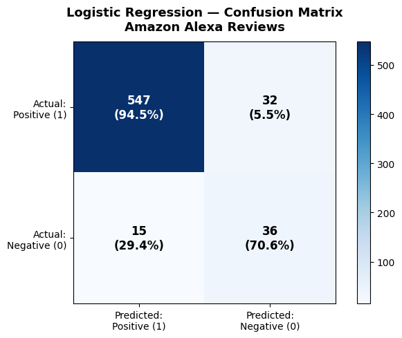

```python
# ============================================
# CONFUSION MATRIX HEATMAP
#
# A visual confusion matrix makes the four cells immediately
# readable: True Positives (top-left), False Negatives (top-right),
# False Positives (bottom-left), True Negatives (bottom-right).
#
# Annotating with both the count and the percentage of actual
# class total gives two perspectives simultaneously.
# ============================================

cm = confusion_matrix(y_test, lr_predictions, labels=[1, 0])
labels = ['Positive (1)', 'Negative (0)']

fig, ax = plt.subplots(figsize=(7, 5))

im = ax.imshow(cm, interpolation='nearest', cmap='Blues')
plt.colorbar(im, ax=ax)

ax.set_xticks([0, 1])
ax.set_yticks([0, 1])
ax.set_xticklabels([f'Predicted:\n{l}' for l in labels], fontsize=10)
ax.set_yticklabels([f'Actual:\n{l}' for l in labels], fontsize=10)

# Annotate each cell with count and row percentage
row_totals = cm.sum(axis=1, keepdims=True)
cm_pct = cm / row_totals * 100
thresh = cm.max() / 2
for i in range(2):
    for j in range(2):
        color = 'white' if cm[i, j] > thresh else 'black'
        ax.text(j, i, f'{cm[i, j]}\n({cm_pct[i, j]:.1f}%)',
                ha='center', va='center', color=color, fontsize=12, fontweight='bold')

ax.set_title('Logistic Regression — Confusion Matrix\nAmazon Alexa Reviews',
             fontsize=13, fontweight='bold', pad=12)
plt.tight_layout()
plt.savefig('alexa_confusion_matrix.png', dpi=150, bbox_inches='tight')
plt.show()
```

## Step 7: Most Informative Features

One advantage of logistic regression over Naïve Bayes is that the model coefficients are directly interpretable as feature weights. The tokens with the highest positive coefficients are the strongest predictors of a positive review; the most negative coefficients flag language associated with negative reviews.

```python
# ============================================
# MOST INFORMATIVE FEATURES
#
# lr_model.coef_[0] returns the coefficient for each TF-IDF feature.
# Higher coefficients push the prediction toward positive (1).
# More negative coefficients push toward negative (0).
#
# argsort() gives indices that would sort the array — we use it
# to find the top and bottom coefficients without sorting the whole array.
# ============================================

feature_names = tv.get_feature_names_out()
coefficients  = lr_model.coef_[0]

# Top 15 most positive and most negative features
top_pos_idx = coefficients.argsort()[-15:][::-1]
top_neg_idx = coefficients.argsort()[:15]

print("Top 15 features predicting POSITIVE feedback:")
print("-" * 45)
for idx in top_pos_idx:
    print(f"  {feature_names[idx]:<30} {coefficients[idx]:+.4f}")

print("\nTop 15 features predicting NEGATIVE feedback:")
print("-" * 45)
for idx in top_neg_idx:
    print(f"  {feature_names[idx]:<30} {coefficients[idx]:+.4f}")
```

```
Top 15 features predicting POSITIVE feedback:
---------------------------------------------
  love                           +5.4670
  great                          +4.0633
  easy                           +2.9268
  works                          +2.0175
  fun                            +1.9374
  like                           +1.7472
  music                          +1.7338
  well                           +1.6524
  far                            +1.5875
  perfect                        +1.5850
  expected                       +1.5547
  amazing                        +1.5365
  best                           +1.5162
  learning                       +1.4199
  works great                    +1.3934

Top 15 features predicting NEGATIVE feedback:
---------------------------------------------
  back                           -2.7294
  amazon                         -2.3635
  didnt                          -2.3584
  working                        -2.3290
  poor                           -2.0511
  work                           -2.0313
  dont                           -1.9641
  would                          -1.9200
  terrible                       -1.9108
  return                         -1.9004
  doesnt                         -1.8870
  refurbished                    -1.8787
  money                          -1.8025
  try                            -1.6947
  useless                        -1.6789
```

## Step 8: Out-of-Sample Predictions

The final test is applying the model to reviews it has never seen — text I wrote myself that wasn't in the training or test data. This is the most direct demonstration that the model has generalized rather than just memorized.

```python
# ============================================
# OUT-OF-SAMPLE PREDICTIONS
#
# These reviews were written fresh — not from the dataset.
# We apply the same clean_text() function used during training,
# then transform with tv.transform() (NOT fit_transform —
# the vocabulary is already fixed from training data).
#
# predict_proba() returns [P(negative), P(positive)] for each review.
# The confidence score is the probability of the predicted class.
# ============================================

custom_reviews = [
    "This product is absolutely amazing, I use it every single day and love every feature",
    "Terrible product, it broke after one week and customer service was useless",
    "It is okay, nothing special but it does what it says on the box",
    "Alexa never understands what I am saying and keeps playing the wrong songs",
    "Best purchase I have made all year, I highly recommend this to everyone",
    "Stopped working after three months, total waste of money, very disappointed",
    "Setup was incredibly easy and the sound quality is surprisingly good for the price"
]

# Clean and vectorize using the training vocabulary
custom_cleaned = [clean_text(r) for r in custom_reviews]
custom_tfidf   = tv.transform(custom_cleaned)
custom_preds   = lr_model.predict(custom_tfidf)
custom_probs   = lr_model.predict_proba(custom_tfidf)

print("Out-of-Sample Review Predictions")
print("=" * 70)
for review, pred, prob in zip(custom_reviews, custom_preds, custom_probs):
    label      = 'POSITIVE' if pred == 1 else 'NEGATIVE'
    confidence = max(prob)
    print(f"\nReview:     {review[:75]}")
    print(f"Prediction: {label}  |  Confidence: {confidence:.1%}")
```

```
Out-of-Sample Review Predictions
======================================================================

Review:     This product is absolutely amazing, I use it every single day and love ever
Prediction: POSITIVE  |  Confidence: 90.0%

Review:     Terrible product, it broke after one week and customer service was useless
Prediction: NEGATIVE  |  Confidence: 76.9%

Review:     It is okay, nothing special but it does what it says on the box
Prediction: NEGATIVE  |  Confidence: 52.8%

Review:     Alexa never understands what I am saying and keeps playing the wrong songs
Prediction: POSITIVE  |  Confidence: 52.6%

Review:     Best purchase I have made all year, I highly recommend this to everyone
Prediction: POSITIVE  |  Confidence: 78.6%

Review:     Stopped working after three months, total waste of money, very disappointed
Prediction: NEGATIVE  |  Confidence: 94.0%

Review:     Setup was incredibly easy and the sound quality is surprisingly good for th
Prediction: POSITIVE  |  Confidence: 77.3%
```

**Reference**

Sarkar, D. (2019). *Text analytics with Python: A practitioner's guide to natural language processing* (2nd ed.). Apress.